# Business Analytics Final Project Report - Consumer Preference on Film Category

Writers:  
Wenye Li, 15020112  
Yan Wang, 15020195

# 1. Introduction

In recent years, Chinese film industry is growing increasingly fast. With more and more people choose to seat in a cinema during their leisure time, more and more capital flows in. One important indicator that investors and film-makers are concerned with is box-office. They always expect a large box-office. But what kinds of films can successfully reach this target? Last year, Wolf Warriors 2 won the champion on the top Chinese box-office list, which also became the first one on the world box-office rank. This patriotic action film was said to be a milestone in Chinese film history. Later in the second half of 2017, historical feature film Youth, fantasy and comedy film Never Say Die also gained considerably large box-office and remarkable reputation. These are mere three successful examples. What type of films on earth conforms to consumer preference nowadays? This is what we are now determined to answer.

# 2. Methodology

## a. Dataset

Firstly, we build a Python spider to crawl data.  
(Note: The following is python code!)

```r
# -*- coding: utf-8 -*-
#Write a Douban movie short comment spider and crawl the data
#Import all the necessary modules
from urllib import request
from http import cookiejar
from urllib import parse
from bs4 import BeautifulSoup
import re
import time
import socket


#Create movie id list
movie_list = []
f = open('movies.txt','r')
afile = f.readlines()
for movieid in afile:
    movie = movieid.strip()
    if movie != '':
        movie_list.append(movie)
f.close()


#Create target url
def MakeUrl(movieid,start):
    url = 'https://movie.douban.com/subject/' + movieid + '/comments?start=' + str(start) + '&limit=20&sort=new_score&status=P'
    return url


#Crawl short comments and save to a folder named "data"
def shortcomment_getter(movieid):
    #Log in to movie.douban.com
    main_url = 'https://accounts.douban.com/login?source=movie'
    formdata = {
        "form_email":"5945slrainbow@sina.com",
        "form_password":"5495sl1219",
        "source":"movie",
        "redir":"https://movie.douban.com/subject/"+movieid,
        "login":"登录"
    }
    user_agent = r'Mozilla/5.0 (Windows NT 10.0; Win64; x64) AppleWebKit/537.36 (KHTML, like Gecko) Chrome/64.0.3282.140 Safari/537.36 Edge/17.17134'
    headers = {'User-Agnet': user_agent, 'Connection': 'keep-alive'}
  #Save cookies
    cookie = cookiejar.CookieJar()
    cookie_support = request.HTTPCookieProcessor(cookie)
    opener = request.build_opener(cookie_support)
  #Get webpage content
    logingpostdata = parse.urlencode(formdata).encode('utf-8')
    req_ligin = request.Request(url=main_url, data=logingpostdata, headers=headers)
    response_login = opener.open(req_ligin).read().decode('utf-8')

    try: #Normally, we are asked to enter captcha in order to log in. Therefore, we need to in advance know what captcha is.
      #Get captcha
        soup = BeautifulSoup(response_login, "html.parser")
        captchaAddr = soup.find('img', id='captcha_image')#['src']
        reCaptchaID = r'<input type="hidden" name="captcha-id" value="(.*?)"/'
        captchaID = re.findall(reCaptchaID, response_login)
        request.urlretrieve(captchaAddr, "captcha.jpg")
    #Input the required captcha and login again
        captcha = input('Please input the captcha:')
        formdata['captcha-solution'] = captcha
        formdata['captcha-id'] = captchaID[0]
        logingpostdata = parse.urlencode(formdata).encode('utf-8')
        req_ligin = request.Request(url=main_url, data=logingpostdata, headers=headers)
        response_login = opener.open(req_ligin).read().decode('utf-8')

  finally: #Run after entering captcha and logging in successfully
    #Get short comment content
        soup = BeautifulSoup(response_login, "html.parser")
        #totalnum = soup.select("div.mod-hd h2 span a")[0].get_text()[3:-2]

        #Calculate page number
        #pagenum = int(totalnum) // 20
        #commentnum = int(totalnum) % 20
        #print(pagenum, commentnum)

        #Deal with error messages
        timeout = 3
        socket.setdefaulttimeout(timeout)

        #Save short comments to txt files
        filename = movieid + '.txt'
        with open(filename, 'w+', encoding='utf-8') as file:
            for item in range(0,9):
                start = item * 20
                url = MakeUrl(movieid,start)
                state = False
                while not state:
                    try:
                        html = opener.open(url).read().decode('utf-8')
                        state = True
                    except socket.timeout:
                        state = False
                soup = BeautifulSoup(html, "html.parser")
                comments = soup.select("div.comment > p")
                for text in comments:
                    file.write(text.get_text()) #.split()[0] + '\n')
                    print(text.get_text())

                    #limit_num = 0
                    #if item == pagenum - 1:
                        #limit_num =+ 1
                        #if limit_num == commentnum:
                            #break

                time.sleep(3)
        print('Done!')


#Call the function and get data
shortcomment_getter(movie_list[i])
```

```r
# -*- coding: utf-8 -*-
#Import necessary modules
import re
import os
from collections import Counter
import jieba
import pandas as pd
import csv


#Create stopword list
stopword_list = []
fi = open('chineseStopWords.txt', 'r')
file = fi.readlines()
for seg in file:
    aseg = seg.strip()
    stopword_list.append(aseg)
fi.close()


#Clean data and do wordcutting
def data_cutter(filename):
    onemovie_allcomments = ''
    folder = r'data\\'
    path = os.path.join(folder, filename)
    with open(path,'rb') as f:
        file = f.read().decode('utf-8').split()
        for comment in file:
            onemovie_allcomments = onemovie_allcomments + comment

    #Get rid of unwanted letters, numbers, punctuations and so on
    pattern = re.compile(r'[\u4e00-\u9fa5]+')
    filterdata = re.findall(pattern, onemovie_allcomments)
    cleaned_comments = ''.join(filterdata)

    #Jieba word cutting
    segment = jieba.lcut(cleaned_comments)

    #Get rid of stopwords
    segword = []
    for seg in segment:
        if seg not in stopword_list:
            segword.append(seg)

    return segword


#Get top 500 keywords that most frequently appear
def keyword_counter(segword):
    frequent_segs = Counter(segword)
    keeper = frequent_segs.most_common(500)
    getter = []
    for atuple in keeper:
        getter.append(atuple[0])

    return getter


vectors = []


def isin_vectorfinal(alist, filename):
    segment = data_cutter(filename)
    avector = []
    t = 0
    while t<len(alist):
        if alist[t] in segment:
            avector.append(1)
        if alist[t] not in segment:
            avector.append(0)
        t+=1
    vectors.append(avector)


#Create a list containing top 100 keywords that most frequently appear within all the short comments for 100 movies
keywords_inonefile = []
fs = os.listdir('data\\')
i = 0
while i<100:
    p = data_cutter(fs[i])
    q = keyword_counter(p)
    keywords_inonefile.extend(q)
    i+=1
vector = Counter(keywords_inonefile).most_common(100)
vector_final = []
k = 0
while k < len(vector):
    vector_final.append(vector[k][0])
    k+=1
z = 0
while z<100:
    isin_vectorfinal(vector_final, fs[z])
    z+=1


#Create a csv dataframe
head = ['Factors']
header = head+vector_final
a = 0
fileobj = open('moviekeywords.csv','w+', newline = '')
writer = csv.writer(fileobj, dialect='excel')
'''
head = head.append('Factors')
while a<700:
    head = head.append(vector_final[a])
    a+=1
#header = head.extend(vector_final)
'''
writer.writerow(header)
w = 0
while w<100:
    num = w+1
    line = [num]+vectors[w]
    #line = [fs[w]].extend(vectors[w])
    writer.writerow(line)
    w+=1
fileobj.close()
print("The end.")
```

The operations above eventually build a csv file named “moviekeywords.csv”. Within this file, we have y-vector to represent those 100 films and x-vector to present all the selected keywords. Before importing it to R environment, we transpose this dataframe. In so doing, after conducting clustering on this transposed dataframe later on, we are able to cluster these property keywords and figure out those preferred film types.

Now, let’s use this file and step to further analysis in R.

## b. Hierarchical Clustering Model

We’ve already extracted keywords that can indicate the properties of popular films from short reviews. Next, we are going to use hierarchical clustering to show the implicit classification.

```r
#Import dataset
keywords=read.csv("moviekeywords.csv")
str(keywords)
```

```
## 'data.frame':    100 obs. of  101 variables:
##  $ Factors: Factor w/ 100 levels "爱情","包袱",..: 73 43 54 28 74 21 29 32 83 25 ...
##  $ X1     : int  1 1 1 0 1 1 1 1 1 1 ...
##  $ X2     : int  1 0 1 0 1 1 1 1 0 1 ...
##  $ X3     : int  1 1 1 0 0 1 1 1 1 1 ...
##  $ X4     : int  0 0 0 1 1 0 0 0 0 1 ...
##  $ X5     : int  1 1 1 1 1 1 1 1 0 1 ...
##  $ X6     : int  1 1 1 0 1 1 0 1 0 1 ...
##  $ X7     : int  1 1 1 1 1 1 1 1 1 0 ...
##  $ X8     : int  1 1 1 0 1 1 1 1 1 1 ...
##  $ X9     : int  1 1 0 0 0 1 1 1 1 1 ...
##  $ X10    : int  1 1 0 1 1 0 1 1 0 1 ...
##  $ X11    : int  1 1 1 1 1 1 1 0 1 1 ...
##  $ X12    : int  1 0 1 1 1 1 1 1 0 0 ...
##  $ X13    : int  1 1 1 1 1 1 1 1 1 1 ...
```

[output cut: 86 more lines]

```r
#Compute distances
distances = dist(keywords[2:101], method = "euclidean")
```

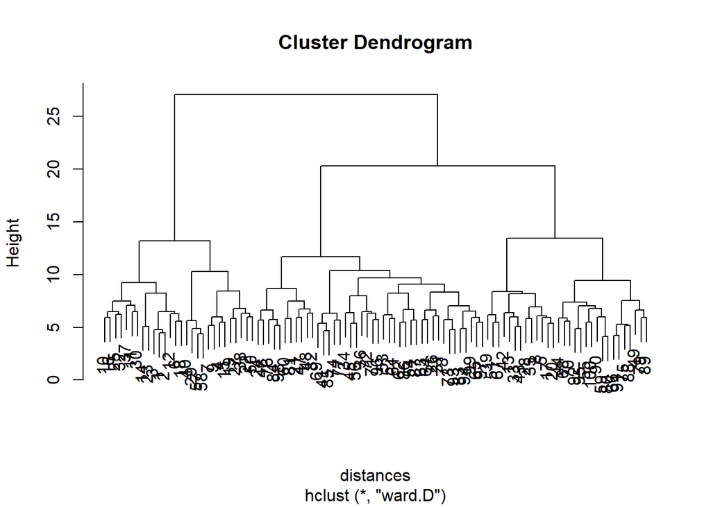

```r
#Hierarchical clustering
clusterkeywords = hclust(distances, method = "ward.D")
#Plot the dendrogram
plot(clusterkeywords)
```

Previously, when doing clustering, we tended to use an arbitrary cluster number. This is barely scientifically sound. We are to utilize a package named “NbClust” this time. Within this package, there are a group of criteria used to assess the effect of different cluster numbers. Function “NbClust” will present the cluster number that redults in the optimal value of criteria overall.

```r
#Use package "NbClust" to determine the proper number of clusters
library(NbClust)
devAskNewPage(ask=TRUE)
nc<-NbClust(keywords[2:101], distance="euclidean", min.nc = 4, max.nc = 15, method = "ward.D", index="duda")
#nc
table(nc$Best.nc) #Show the recommended cluster number
```

```
##
## 0.9386      5
##      1      1
```

According to “NbClust” result, cluster number as 5 is the best case. Now that we’ve decided the group number, we start to cluster all the observations.

```r
#Assign points to clusters
clusterGroups = cutree(clusterkeywords, k=5)
```

Now let’s see what we have in each cluster.

```r
cluster1 = subset(keywords, clusterGroups==1)
cluster1$Factors
```

```
##  [1] 套路 惊喜 亮点 反派 感动 平庸 致敬 老套 情怀 经典 俗套 现实 惊艳 诚意
## [15] 深刻
## 100 Levels: 爱情 包袱 暴力 爆米花 爆炸 悲剧 彩蛋 诚意 冲突 创意 戳 ... 走心
```

```r
cluster2 = subset(keywords, clusterGroups==2)
cluster2$Factors
```

```
##  [1] 搞笑 梗   笑点 喜剧 生硬 国产 流畅 好笑 突破 幽默 浮夸 笑料 段子
## 100 Levels: 爱情 包袱 暴力 爆米花 爆炸 悲剧 彩蛋 诚意 冲突 创意 戳 ... 走心
```

```r
cluster3 = subset(keywords, clusterGroups==3)
cluster3$Factors
```

```
##  [1] 特效   好莱坞 英雄   大片   爆米花 美国   打斗   续集   商业片 大战
## [11] 科幻片 爆炸   无脑
## 100 Levels: 爱情 包袱 暴力 爆米花 爆炸 悲剧 彩蛋 诚意 冲突 创意 戳 ... 走心
```

```r
cluster4 = subset(keywords, clusterGroups==4)
cluster4$Factors
```

```
##  [1] 爱情   彩蛋   煽情   感人   真实   政治   改编   人性   欢乐   美好
## [11] 精致   创意   转折   夸张   冲突   娱乐   反转   包袱   戳     泪点
## [21] 动人   小说   正义   鲜肉   温情   奇幻   动画   廉价   家庭   幻想
## [31] 矛盾   鸡汤   冒险   原著   喜剧片 走心   亲情   励志   悲剧   怀旧
## [41] 热闹   原创
## 100 Levels: 爱情 包袱 暴力 爆米花 爆炸 悲剧 彩蛋 诚意 冲突 创意 戳 ... 走心
```

```r
cluster5 = subset(keywords, clusterGroups==5)
cluster5$Factors
```

```
##  [1] 震撼   混乱   过瘾   爽     暴力   刺激   紧张   打戏   华语   动作片
## [11] 枪战   港片   恐怖   血腥   悬念   悬疑   卡司
## 100 Levels: 爱情 包袱 暴力 爆米花 爆炸 悲剧 彩蛋 诚意 冲突 创意 戳 ... 走心
```

# 3. Finding

Recall that movies we chose are Top 100 for 2017 in terms of box-office. What we’ve been analyzing, in fact, is movie types that make up these 100 movies. The result shows that there are 5 clusters, which means there are implicitly five types out of the 100 movies. We now discuss these clusters one by one.

In the first cluster, we find words “套路”, “致敬”, “情怀”, “经典” and the like. Thus we can assume that films, such as Murder on the Orient Express and A Chinese Odyssey Part Two – Cinderella, characterized by remaking or reshowing of classic old films, are one of consumers’ favorite choice.

Words in the second cluster, for instance “搞笑”, “梗” and “幽默”, suggest that audience have a strong preference to comedies. What is worth noticing is the word “国产”. This one provides us with important implication. Actually, there are indeed more than half of the Chinese films on the list are comedies, such as Never Say Die and Buddies in India. In other words, audience are very interested in Chinese funny films.

Keywords from the third group include “特效”, “好莱坞”, “英雄” and “续集”, which is in accordance with the type of Hollywood movies shown in China — those superhero serials. More often than not, they are commercial films with magnificent vision effects. For example, The Fate of the Furious and Transformers: The Last Knight.

Next, films in the fourth cluster are likely to be love stories with IP background and popular young actors like Once Upon a Time, since we have keywords “爱情”, “鲜肉” and “小说” here.

Films in the last type are likely to be Hong Kong gangster films and suspense films like Paradox, judging from keywords “港片”, “枪战” and “悬念”.

Now let’s look at the overall frequency distribution of all the keywords from the Top 100 films for 2017 in terms of box-office. To observe them more directly, we will build a word cloud.

```r
frequency <- read.csv("freq.csv")
library(wordcloud2)
set.seed(142)
wordcloud2(frequency, size = 0.4, fontFamily = '黑体')
```

[interactive chart not shown]

“套路”, “惊喜”, “搞笑” and “特效” are the biggest words we can see, which means they are dominant properties preferred by consumers. We can conclude that the quality of films of domestic cinema chains is uneven to some degree.

The analyses above is a very eﬀective model that can help film industry participators have a clearer cognition of Chinese film viewers’ preference. Knowing such information, Chinese film industry development will be more directed. For example, film directors need to pay more attention to the plot, as a result of the fact that more than half of the film reviewers have stated their dissatisfaction with those old-fashioned plots. Although they might still go to cinema to watch movies, they probably will not pay for a similar one twice. This implies that our film industry lacks maturity. In a word, direct communication through film comments and reviews with audience is powerful. It provides valuable directive insights. In addition, such consumer preference analytics can also be taken as a typical business strategy model, used in other fields where customers’ opinions are extremely critical, such as supply chain purchase and manufacture plan making.